# STAT 155 mini-project

## Plot 2

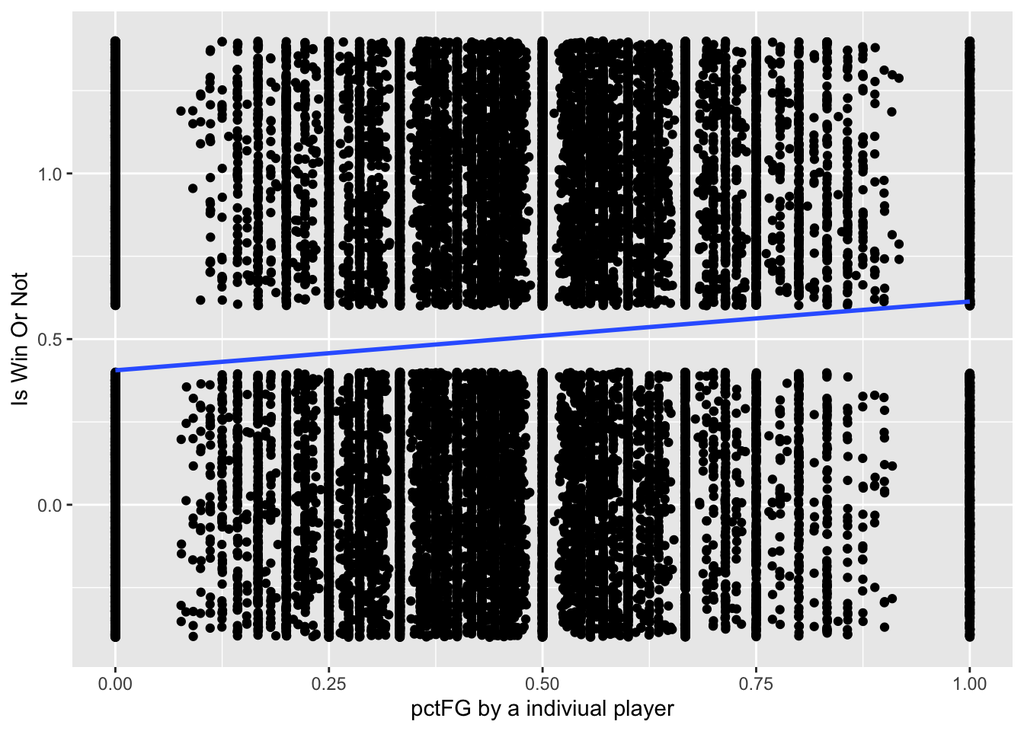

```r
# Plot 2

ggplot(gamedata, aes(x = pctFG, y = as.numeric(isWin))) +
  geom_jitter() +
  geom_smooth(method = "glm", method.args = list(family = "binomial"), se = FALSE, fullrange = TRUE) +
  ylab("Is Win Or Not") + xlab("pctFG by a indiviual player")
```

## Plot 3

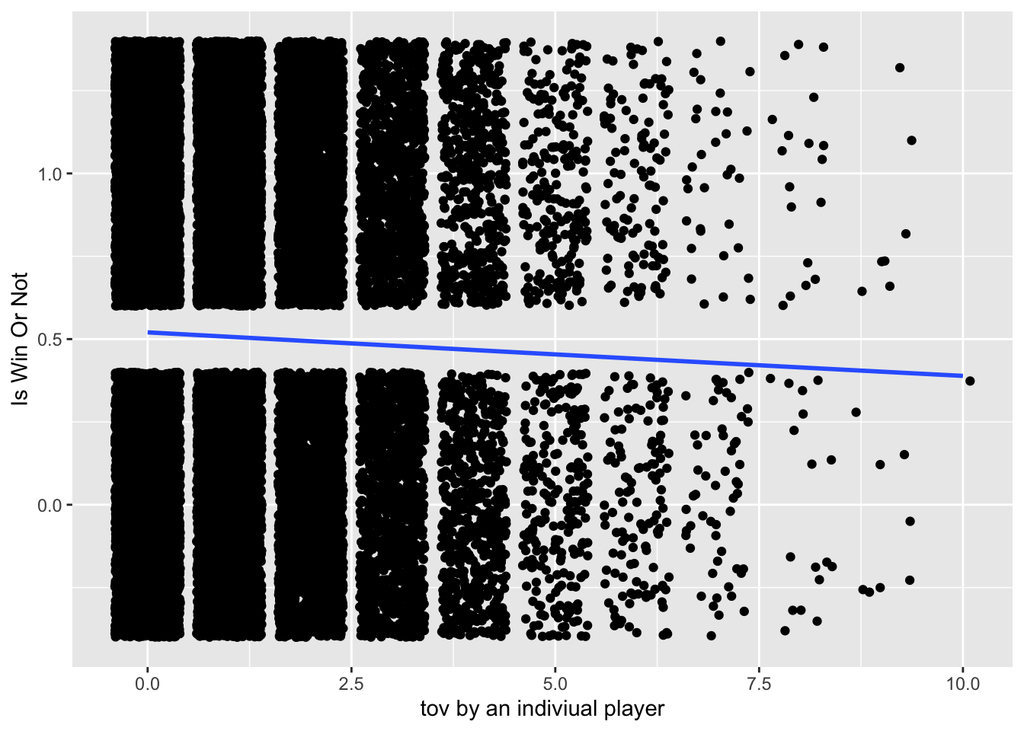

```r
# Plot 3

ggplot(gamedata, aes(x = tov, y = as.numeric(isWin))) +
  geom_jitter() +
  geom_smooth(method = "glm", method.args = list(family = "binomial"), se = FALSE, fullrange = TRUE) +
  ylab("Is Win Or Not")+xlab("tov by an indiviual player")
```

## Plot 4 (if you have one)

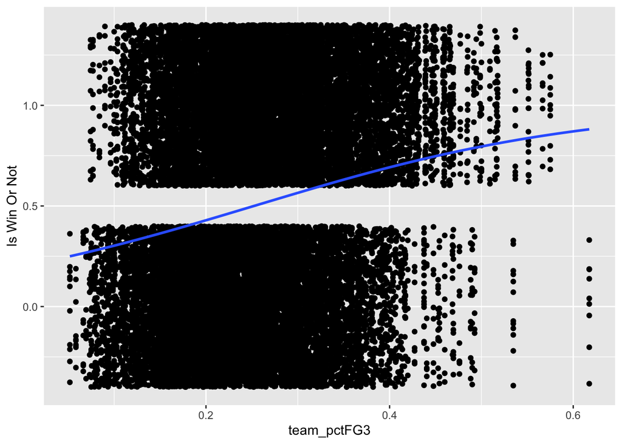

```r
# Plot 4

ggplot(gamedata, aes(x = team_pctFG3, y = as.numeric(isWin))) +
  geom_jitter() +
  geom_smooth(method = "glm", method.args = list(family = "binomial"), se = FALSE, fullrange = TRUE) +
  ylab("Is Win Or Not")+xlab("team_pctFG3")
```

## Plot 5 (if you have one)

This is a logistic model of the relationship between a team’s amount of assists in a game and the probability of their team winning. The chart shows the overall likelihood of victory increases as the teams assists increase. The graph initially increases slowly, but as the assist numbers approach 25, the probability of winning increases much more quickly, until it eventually flattens again.

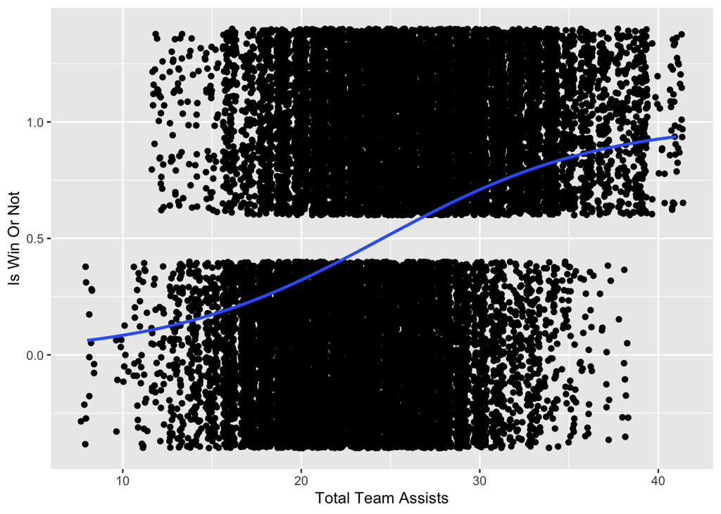

```r
# Plot 5

ggplot(gamedata, aes(x = team_ast, y = as.numeric(isWin))) +
  geom_jitter() +
  geom_smooth(method = "glm", method.args = list(family = "binomial"), se = FALSE, fullrange = TRUE) +
  ylab("Is Win Or Not")+xlab("Total Team Assists")
```

## Plot 6 (if you have one)

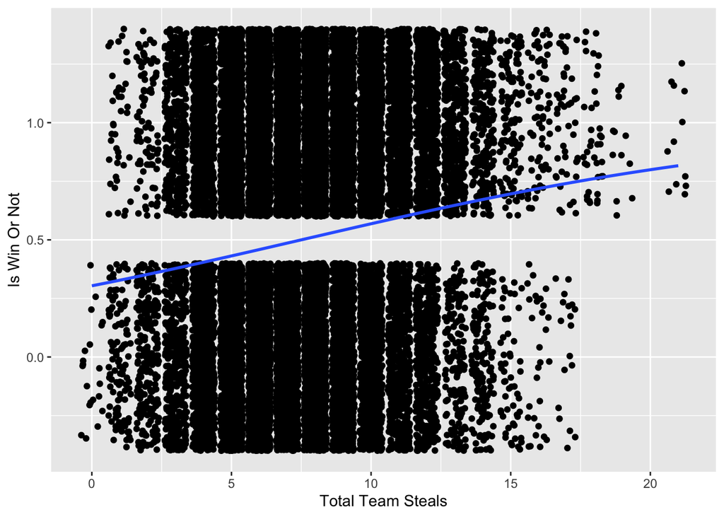

```r
# Plot 6

ggplot(gamedata, aes(x = team_stl, y = as.numeric(isWin))) +
  geom_jitter() +
  geom_smooth(method = "glm", method.args = list(family = "binomial"), se = FALSE, fullrange = TRUE) +
  ylab("Is Win Or Not")+xlab("Total Team Steals")
```

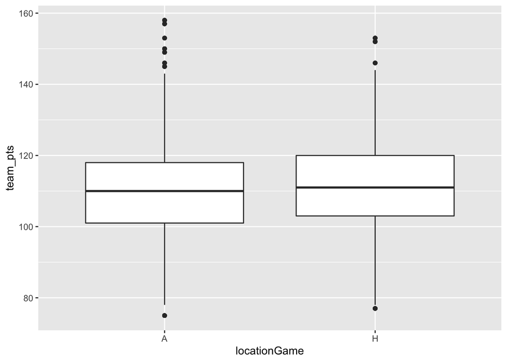

```r
ggplot(gamedata, aes(y = team_pts,x = locationGame)) +
  geom_boxplot()
```

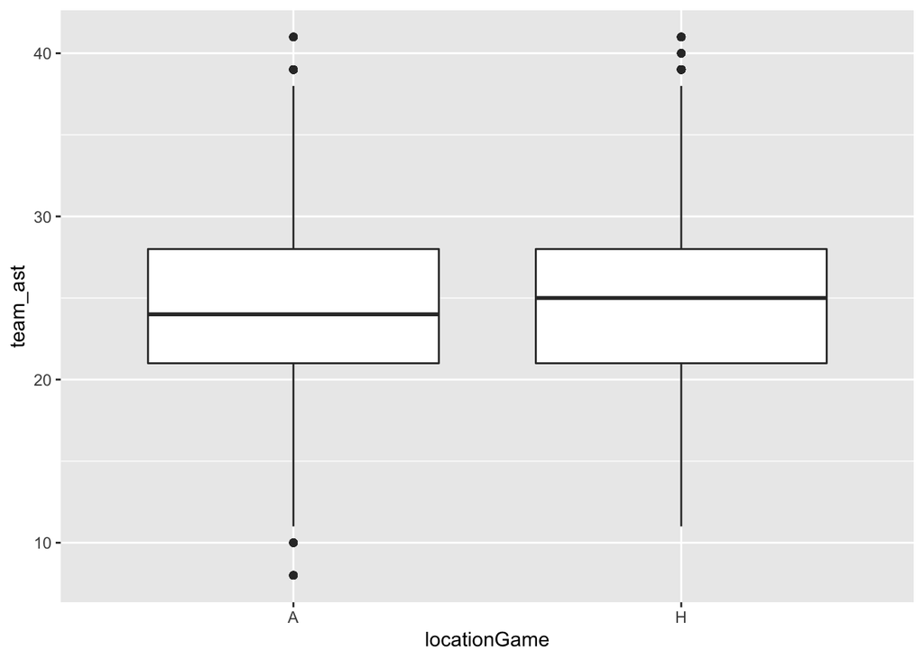

```r
ggplot(gamedata, aes(y = team_ast,x = locationGame)) +
  geom_boxplot()
```

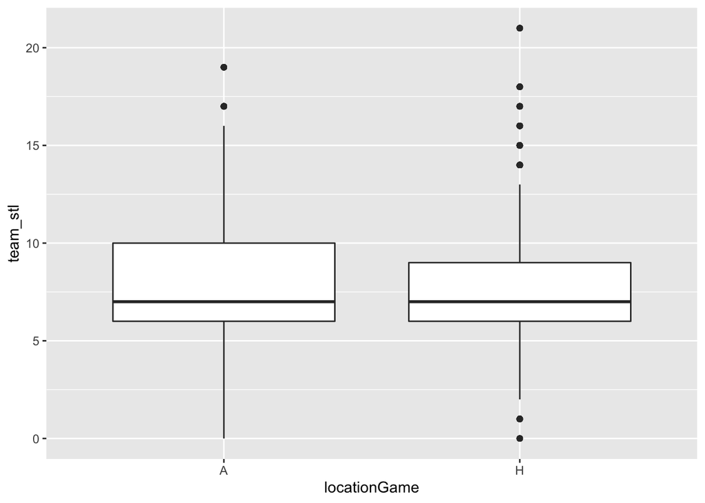

```r
ggplot(gamedata, aes(y = team_stl,x = locationGame)) +
  geom_boxplot()
```

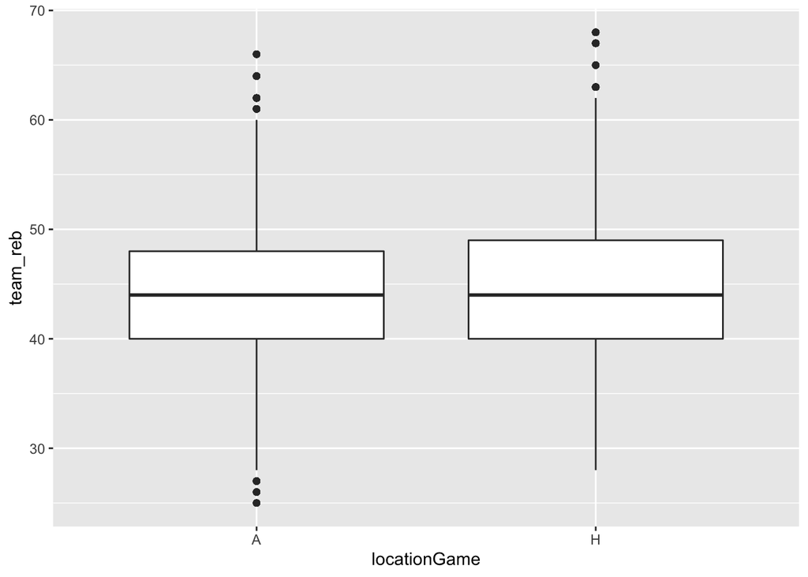

```r
ggplot(gamedata, aes(y = team_reb,x = locationGame)) +
  geom_boxplot()
```

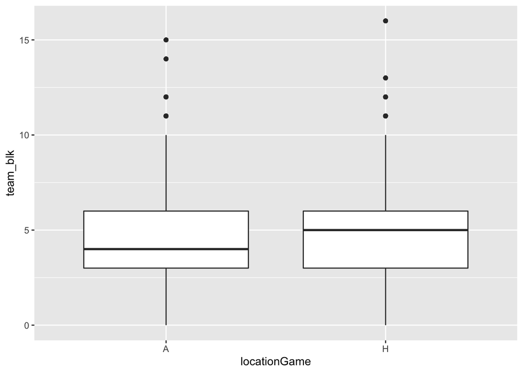

```r
ggplot(gamedata, aes(y = team_blk,x = locationGame)) +
  geom_boxplot()
```

# Models

In the sections below, construct and discuss 2–4 models that inform your research questions. Don’t start with the most complicated model you can think of. This is almost always wrong and tough to interpret if you don’t build up to it. Instead, start with a simple model and build up from there. For each model, you will:

- Specify your model assumptions (eg: is this “normal” or “logistic” regression?).
- Discuss whether this is a “good” model (and include evidence that supports this discussion).
- Interpret your model coefficients. If you have a lot of coefficients, focus on the main points of interest.
- RECOMMENDED but OPTIONAL: Do some inference. What do the confidence intervals and hypothesis tests allow you to conclude about the broader population of interest? (You’ll need to do this for the final presentation, so should start now if you can.)

## Model 1

**Construct and save your model using lm() or glm()**

```r
# Building a team stats that has only team stats
team_stats <-
  gamedata %>%
  select(nameTeam,idGame,locationGame, team_pts,team_ast,team_blk,team_reb,team_stl,isWin) %>%
  arrange(idGame) %>%
  unique()


basketball_model_1 <-
  glm(isWin ~ team_pts + team_ast + team_blk + team_reb + team_stl, data = team_stats)

summary(basketball_model_1)
```

```
##
## Call:
## glm(formula = isWin ~ team_pts + team_ast + team_blk + team_reb +
##     team_stl, data = team_stats)
##
## Deviance Residuals:
##      Min        1Q    Median        3Q       Max
## -1.31314  -0.33234  -0.02732   0.35433   1.09490
##
## Coefficients:
##              Estimate Std. Error t value Pr(>|t|)
## (Intercept) -2.537489   0.090630 -27.998  < 2e-16 ***
## team_pts     0.016504   0.000857  19.257  < 2e-16 ***
## team_ast     0.005608   0.002142   2.618  0.00891 **
## team_blk     0.011248   0.003522   3.194  0.00142 **
## team_reb     0.019853   0.001299  15.285  < 2e-16 ***
## team_stl     0.018114   0.002962   6.116 1.12e-09 ***
## ---
## Signif. codes:  0 '***' 0.001 '**' 0.01 '*' 0.05 '.' 0.1 ' ' 1
##
## (Dispersion parameter for gaussian family taken to be 0.1695795)
##
##     Null deviance: 615.00  on 2459  degrees of freedom
## Residual deviance: 416.15  on 2454  degrees of freedom
## AIC: 2624.1
##
## Number of Fisher Scoring iterations: 2
```

**Specify your model assumptions (eg: is this “normal” or “logistic” regression?)**

**Discuss whether this is a “good” model (and include evidence that supports this discussion)**  
This is a good model because we can see that the p-values for each of the coefficients of the models are extremely small, so these relationships are very likely to exist as they are extremely unlikely to have been seen due to random chance.

**Report a model `summary()` table and interpret your model coefficients. If you have a lot of coefficients, focus on the main points of interest.**

```r
summary(basketball_model_1)
```

```
##
## Call:
## glm(formula = isWin ~ team_pts + team_ast + team_blk + team_reb +
##     team_stl, data = team_stats)
##
## Deviance Residuals:
##      Min        1Q    Median        3Q       Max
## -1.31314  -0.33234  -0.02732   0.35433   1.09490
##
## Coefficients:
##              Estimate Std. Error t value Pr(>|t|)
## (Intercept) -2.537489   0.090630 -27.998  < 2e-16 ***
## team_pts     0.016504   0.000857  19.257  < 2e-16 ***
## team_ast     0.005608   0.002142   2.618  0.00891 **
## team_blk     0.011248   0.003522   3.194  0.00142 **
## team_reb     0.019853   0.001299  15.285  < 2e-16 ***
## team_stl     0.018114   0.002962   6.116 1.12e-09 ***
## ---
## Signif. codes:  0 '***' 0.001 '**' 0.01 '*' 0.05 '.' 0.1 ' ' 1
##
## (Dispersion parameter for gaussian family taken to be 0.1695795)
##
##     Null deviance: 615.00  on 2459  degrees of freedom
## Residual deviance: 416.15  on 2454  degrees of freedom
## AIC: 2624.1
##
## Number of Fisher Scoring iterations: 2
```

```r
exp(0.016504)
```

```
## [1] 1.016641
```

```r
exp(0.005608)
```

```
## [1] 1.005624
```

```r
exp(0.011248)
```

```
## [1] 1.011311
```

```r
exp(0.019853)
```

```
## [1] 1.020051
```

```r
exp(0.018114)
```

```
## [1] 1.018279
```

**Optional but recommended: Check out and discussion some confidence intervals / hypothesis tests.**

## Model 2

**Construct and save your model using lm() or glm()**

```r
basketball_model_2 <-
  lm(team_pts ~ locationGame,data = gamedata)

summary(basketball_model_2)
```

```
##
## Call:
## lm(formula = team_pts ~ locationGame, data = gamedata)
##
## Residuals:
##     Min      1Q  Median      3Q     Max
## -34.701  -8.612   0.299   8.388  48.299
##
## Coefficients:
##               Estimate Std. Error t value Pr(>|t|)
## (Intercept)   109.7010     0.1122  977.32   <2e-16 ***
## locationGameH   1.9112     0.1585   12.06   <2e-16 ***
## ---
## Signif. codes:  0 '***' 0.001 '**' 0.01 '*' 0.05 '.' 0.1 ' ' 1
##
## Residual standard error: 12.78 on 26037 degrees of freedom
## Multiple R-squared:  0.005556,   Adjusted R-squared:  0.005518
## F-statistic: 145.5 on 1 and 26037 DF,  p-value: < 2.2e-16
```

**Specify your model assumptions (eg: is this “normal” or “logistic” regression?)**

We assume that there exists a linear regression between teams pts and locationGame since the thing being predicted is quantitative.

**Discuss whether this is a “good” model (and include evidence that supports this discussion)**

**Report a model `summary()` table and interpret your model coefficients. If you have a lot of coefficients, focus on the main points of interest.**

```r
summary(basketball_model_2)
```

```
##
## Call:
## lm(formula = team_pts ~ locationGame, data = gamedata)
##
## Residuals:
##     Min      1Q  Median      3Q     Max
## -34.701  -8.612   0.299   8.388  48.299
##
## Coefficients:
##               Estimate Std. Error t value Pr(>|t|)
## (Intercept)   109.7010     0.1122  977.32   <2e-16 ***
## locationGameH   1.9112     0.1585   12.06   <2e-16 ***
## ---
## Signif. codes:  0 '***' 0.001 '**' 0.01 '*' 0.05 '.' 0.1 ' ' 1
##
## Residual standard error: 12.78 on 26037 degrees of freedom
## Multiple R-squared:  0.005556,   Adjusted R-squared:  0.005518
## F-statistic: 145.5 on 1 and 26037 DF,  p-value: < 2.2e-16
```

The locationGameH variable shows that teams score an average of two points more per game at home than when they play away from home. This means that the “home-court advantage” is not that significant, as teams only score two more points on average when they are at home.

**Optional but recommended: Check out and discussion some confidence intervals / hypothesis tests.**